# Codes

2022-12-31

Only i will write the codes, she explaned about how to connect Rstudio with Git.

How to call library:

```r
library(ggplot2)
library(tinytex)
"how to call function in Library"
```

```
## [1] "how to call function in Library"
```

```r
"to get working directoy:"
```

```
## [1] "to get working directoy:"
```

```r
getwd()
```

```
## [1] "F:/Rstudio_Work_Station/My new R courseBatool/Zero-to-hero-in-R"
```

```r
"اقدر اكتب بالعربي"
```

```
## [1] "اقدر اكتب بالعربي"
```

```r
"في نفس الشنك فيه يمين فوق علامه اعدادات فيها خيارات اتحكم في الشنك"
```

```
## [1] "في نفس الشنك فيه يمين فوق علامه اعدادات فيها خيارات اتحكم في الشنك"
```

```r
"عدلتها من اعدادت الشنك اني اخليها ينفذ الكود و يظهر لي المخرجات"
```

```
## [1] "عدلتها من اعدادت الشنك اني اخليها ينفذ الكود و يظهر لي المخرجات"
```

```r
"if i writr like this: ##some thing, the text will be bigger in Knit"
```

```
## [1] "if i writr like this: ##some thing, the text will be bigger in Knit"
```

```r
"numberical: 12.5
integer : 5
string: حروف
factor: male
logical: True,false"
```

```
## [1] "numberical: 12.5\ninteger : 5\nstring: حروف\nfactor: male\nlogical: True,false"
```

```r
x <- 5
typeof(x)
```

```
## [1] "double"
```

```r
y <- "Omar"
typeof(y)
```

```
## [1] "character"
```

```r
A <- "55"
typeof(A)
```

```
## [1] "character"
```

```r
is.character(y)
```

```
## [1] TRUE
```

```r
is.double(y)
```

```
## [1] FALSE
```

```r
Q <- FALSE
typeof(Q)
```

```
## [1] "logical"
```

```r
w <- 2/0

w
```

```
## [1] Inf
```

# 1 use c , type of,

```r
v <- c(1,2.5,4,6)
typeof(v)
```

```
## [1] "double"
```

```r
M <- c(2.2,3,"A","b")
typeof(M)
```

```
## [1] "character"
```

```r
"الأولويه للأسترنج"
```

```
## [1] "الأولويه للأسترنج"
```

```r
DS <- c(TRUE,3,7.2)
typeof(DS)
```

```
## [1] "double"
```

# 2 sequence data and using ?,?? fro exploaring libraryes

```r
"عشان اعرف عن مكتبه و طريقه استخدامها لازم اكتب استفهام و اسم المكتبه  في الكونسول الي تحت هذي النافذه"
```

```
## [1] "عشان اعرف عن مكتبه و طريقه استخدامها لازم اكتب استفهام و اسم المكتبه  في الكونسول الي تحت هذي النافذه"
```

```r
?seq
```

```
## starting httpd help server ... done
```

```r
??seq


DSD <- seq(1:20)
FDS <- seq(4,20, by=2)
```

#change the data type,“the below code make me able to change the data type from double to integer, just use: as.type of data i want”

```r
typeof(5)
```

```
## [1] "double"
```

```r
as.integer(x)
```

```
## [1] 5
```

```r
Dateee <- 1-1-2023
typeof(Dateee)
```

```
## [1] "double"
```

```r
as.character.Date(Dateee)
```

```
## [1] "-2023"
```

#explain

```r
"
3**9 :
ثلاثه اوس تسعه
Sqrt(9) = 3 :
الجذر
3+3*5 = 18
هنا الاولوليه للضرب
اذا حاب اجمع او ف اسوي كذى:
(3+5)*3
-
Titoruial ((تدريب عملي من نفس الار ستوديو ، يكون محله جمب المتغيرا الي نعرفه فوق يمين

"
```

```
## [1] "\n3**9 :\nثلاثه اوس تسعه\nSqrt(9) = 3 :\nالجذر\n3+3*5 = 18\nهنا الاولوليه للضرب\nاذا حاب اجمع او ف اسوي كذى:\n(3+5)*3\n-\nTitoruial ((تدريب عملي من نفس الار ستوديو ، يكون محله جمب المتغيرا الي نعرفه فوق يمين\n\n"
```

#explain

```r
"here pacage: it is make me able to open my project from multible devices with out mistakes in working directory
"
```

```
## [1] "here pacage: it is make me able to open my project from multible devices with out mistakes in working directory\n"
```

##import data

```r
library(tidyverse)
library(here)
read_csv(here("data","SAFI_clean.csv"))
```

```
## # A tibble: 131 × 14
##    key_ID village  interview_date      no_membrs years_liv respo…¹ rooms memb_…²
##     <dbl> <chr>    <dttm>                  <dbl>     <dbl> <chr>   <dbl> <chr>
##  1      1 God      2016-11-17 00:00:00         3         4 muddaub     1 NULL
##  2      1 God      2016-11-17 00:00:00         7         9 muddaub     1 yes
##  3      3 God      2016-11-17 00:00:00        10        15 burntb…     1 NULL
##  4      4 God      2016-11-17 00:00:00         7         6 burntb…     1 NULL
##  5      5 God      2016-11-17 00:00:00         7        40 burntb…     1 NULL
##  6      6 God      2016-11-17 00:00:00         3         3 muddaub     1 NULL
##  7      7 God      2016-11-17 00:00:00         6        38 muddaub     1 no
##  8      8 Chirodzo 2016-11-16 00:00:00        12        70 burntb…     3 yes
##  9      9 Chirodzo 2016-11-16 00:00:00         8         6 burntb…     1 no
## 10     10 Chirodzo 2016-12-16 00:00:00        12        23 burntb…     5 no
## # … with 121 more rows, 6 more variables: affect_conflicts <chr>,
## #   liv_count <dbl>, items_owned <chr>, no_meals <dbl>, months_lack_food <chr>,
## #   instanceID <chr>, and abbreviated variable names ¹respondent_wall_type,
## #   ²memb_assoc
## # ℹ Use `print(n = ...)` to see more rows, and `colnames()` to see all variable names
```

```r
Datafile <- read.csv(here("data","SAFI_clean.csv"), na = "NULL")
```

#“data type:”

```r
glimpse(Datafile)
```

```
## Rows: 131
## Columns: 14
## $ key_ID               <int> 1, 1, 3, 4, 5, 6, 7, 8, 9, 10, 11, 12, 13, 14, 15…
## $ village              <chr> "God", "God", "God", "God", "God", "God", "God", …
## $ interview_date       <chr> "2016-11-17T00:00:00Z", "2016-11-17T00:00:00Z", "…
## $ no_membrs            <int> 3, 7, 10, 7, 7, 3, 6, 12, 8, 12, 6, 7, 6, 10, 5, …
## $ years_liv            <int> 4, 9, 15, 6, 40, 3, 38, 70, 6, 23, 20, 20, 8, 20,…
## $ respondent_wall_type <chr> "muddaub", " muddaub", " burntbricks", " burntbri…
## $ rooms                <int> 1, 1, 1, 1, 1, 1, 1, 3, 1, 5, 1, 3, 1, 3, 2, 1, 1…
## $ memb_assoc           <chr> NA, "yes", NA, NA, NA, NA, "no", "yes", "no", "no…
## $ affect_conflicts     <chr> NA, "once", NA, NA, NA, NA, "never", "never", "ne…
## $ liv_count            <int> 1, 3, 1, 2, 4, 1, 1, 2, 3, 2, 2, 2, 3, 3, 3, 4, 1…
## $ items_owned          <chr> "bicycle;television;solar_panel;table", "cow_cart…
## $ no_meals             <int> 2, 2, 2, 2, 2, 2, 3, 2, 3, 3, 2, 3, 2, 3, 2, 3, 2…
## $ months_lack_food     <chr> "Jan", "Jan;Sept;Oct;Nov;Dec", "Jan;Feb;Mar;Oct;N…
## $ instanceID           <chr> "uuid:ec241f2c-0609-46ed-b5e8-fe575f6cefef", "uui…
```

```r
Datafile$no_membrs
```

```
##   [1]  3  7 10  7  7  3  6 12  8 12  6  7  6 10  5  6  8  4  9  6  8  4 10  6 11
##  [26]  3  7  2  7  7  3 19  8  8  5  6  3 10  6  9  7  8  7  2  9 10  2  7  6  6
##  [51]  5 11  8  7  9 12  4 11  2  8 10  5  4  6  8 10  5  8  4  8  6  4  5 10  5
##  [76]  4  5 10  7 11  7  7  5  5  7  5  3  4 12  6  7 17  5  7  5  3  6 12  6  5
## [101] 14  6 15  4  6 11  5  5  3  4 15  5 10  7 10  7  4  7  9 11  8 12  7 15 10
## [126]  9  3  7  4  7  8
```

```r
no_of_member <- Datafile$no_membrs

view(no_of_member)
"showed what is unique in the data"
```

```
## [1] "showed what is unique in the data"
```

```r
unique(no_of_member)
```

```
##  [1]  3  7 10  6 12  8  5  4  9 11  2 19 17 14 15
```

```r
unique(Datafile)
```

```
##     key_ID  village       interview_date no_membrs years_liv
## 1        1      God 2016-11-17T00:00:00Z         3         4
## 2        1      God 2016-11-17T00:00:00Z         7         9
## 3        3      God 2016-11-17T00:00:00Z        10        15
## 4        4      God 2016-11-17T00:00:00Z         7         6
## 5        5      God 2016-11-17T00:00:00Z         7        40
## 6        6      God 2016-11-17T00:00:00Z         3         3
## 7        7      God 2016-11-17T00:00:00Z         6        38
## 8        8 Chirodzo 2016-11-16T00:00:00Z        12        70
## 9        9 Chirodzo 2016-11-16T00:00:00Z         8         6
## 10      10 Chirodzo 2016-12-16T00:00:00Z        12        23
## 11      11      God 2016-11-21T00:00:00Z         6        20
## 12      12      God 2016-11-21T00:00:00Z         7        20
## 13      13      God 2016-11-21T00:00:00Z         6         8
## 14      14      God 2016-11-21T00:00:00Z        10        20
```

[output cut: 645 more lines]

```r
"length: show as number how many unique value:"
```

```
## [1] "length: show as number how many unique value:"
```

```r
length(unique(no_of_member))
```

```
## [1] 15
```

```r
length(unique(Datafile))
```

```
## [1] 14
```

```r
Datafile %>%
  select(village,no_membrs, months_lack_food)
```

```
##      village no_membrs                               months_lack_food
## 1        God         3                                            Jan
## 2        God         7                           Jan;Sept;Oct;Nov;Dec
## 3        God        10                        Jan;Feb;Mar;Oct;Nov;Dec
## 4        God         7                               Sept;Oct;Nov;Dec
## 5        God         7                               Aug;Sept;Oct;Nov
## 6        God         3                                   Aug;Sept;Oct
## 7        God         6                                            Nov
## 8   Chirodzo        12                                            Jan
## 9   Chirodzo         8                                        Jan;Dec
## 10  Chirodzo        12                                Jan;Oct;Nov;Dec
## 11       God         6                                        Oct;Nov
## 12       God         7                                       Sept;Oct
## 13       God         6                                   Sept;Oct;Nov
## 14       God        10                     June;July;Aug;Sept;Oct;Nov
```

[output cut: 117 more lines]

```r
Only <- Datafile %>%
  select(village,no_membrs, months_lack_food)
"this code below with -c means delet the selected data"
```

```
## [1] "this code below with -c means delet the selected data"
```

```r
delet_few <- Datafile %>%
  select(-c(village,no_membrs))

"this code below with -c means delet the selected data, using : to select From .. To .."
```

```
## [1] "this code below with -c means delet the selected data, using : to select From .. To .."
```

```r
delet_few_fwe <- Datafile %>%
  select(-c(village:no_membrs))
"using select with filter to chose what i need from the dataset"
```

```
## [1] "using select with filter to chose what i need from the dataset"
```

```r
SSelect <- Datafile %>%
  select(village:years_liv) %>%
  filter(village == "God",
         years_liv > 24)

Datafile$village=="God"
```

```
##   [1]  TRUE  TRUE  TRUE  TRUE  TRUE  TRUE  TRUE FALSE FALSE FALSE  TRUE  TRUE
##  [13]  TRUE  TRUE  TRUE  TRUE  TRUE  TRUE  TRUE  TRUE  TRUE  TRUE FALSE FALSE
##  [25] FALSE FALSE FALSE FALSE FALSE FALSE FALSE FALSE FALSE FALSE FALSE FALSE
##  [37] FALSE  TRUE  TRUE  TRUE  TRUE  TRUE FALSE FALSE FALSE FALSE FALSE FALSE
##  [49] FALSE FALSE FALSE FALSE FALSE FALSE FALSE FALSE FALSE FALSE FALSE FALSE
##  [61] FALSE FALSE FALSE FALSE FALSE FALSE FALSE FALSE FALSE FALSE FALSE FALSE
##  [73] FALSE FALSE FALSE  TRUE FALSE  TRUE FALSE  TRUE  TRUE  TRUE  TRUE  TRUE
##  [85]  TRUE  TRUE  TRUE  TRUE  TRUE FALSE FALSE FALSE FALSE FALSE  TRUE  TRUE
##  [97] FALSE FALSE FALSE FALSE FALSE FALSE  TRUE  TRUE FALSE FALSE FALSE FALSE
## [109] FALSE FALSE  TRUE FALSE FALSE FALSE FALSE FALSE  TRUE  TRUE FALSE FALSE
## [121] FALSE FALSE FALSE FALSE FALSE FALSE FALSE FALSE FALSE FALSE FALSE
```

```r
samlldata <- Datafile %>%
  select(village:respondent_wall_type,rooms) %>%
  filter(village == "God" & rooms > 1 )


Task <- Datafile %>%
  select(memb_assoc,affect_conflicts,liv_count,no_meals) %>%
  filter(memb_assoc == "yes")

filter(Datafile, memb_assoc == "yes")
```

```
##    key_ID  village       interview_date no_membrs years_liv
## 1       1      God 2016-11-17T00:00:00Z         7         9
## 2       8 Chirodzo 2016-11-16T00:00:00Z        12        70
## 3      12      God 2016-11-21T00:00:00Z         7        20
## 4      15      God 2016-11-21T00:00:00Z         5        30
## 5      29    Ruaca 2016-11-21T00:00:00Z         7        10
## 6      32    Ruaca 2016-11-21T00:00:00Z        19        69
## 7      34 Chirodzo 2016-11-17T00:00:00Z         8        18
## 8      35 Chirodzo 2016-11-17T00:00:00Z         5        45
## 9      36 Chirodzo 2016-11-17T00:00:00Z         6        23
## 10     38      God 2016-11-17T00:00:00Z        10        19
## 11     40      God 2016-11-17T00:00:00Z         9        23
## 12     47 Chirodzo 2016-11-17T00:00:00Z         2         2
## 13     50 Chirodzo 2016-11-16T00:00:00Z         6         7
## 14     21 Chirodzo 2016-11-16T00:00:00Z         8        16
```

[output cut: 155 more lines]

```r
"mutate to generat a new column with our needs from the data"
```

```
## [1] "mutate to generat a new column with our needs from the data"
```

```r
Datafile %>%
  mutate(pepole_per_room = no_membrs / rooms)
```

```
##     key_ID  village       interview_date no_membrs years_liv
## 1        1      God 2016-11-17T00:00:00Z         3         4
## 2        1      God 2016-11-17T00:00:00Z         7         9
## 3        3      God 2016-11-17T00:00:00Z        10        15
## 4        4      God 2016-11-17T00:00:00Z         7         6
## 5        5      God 2016-11-17T00:00:00Z         7        40
## 6        6      God 2016-11-17T00:00:00Z         3         3
## 7        7      God 2016-11-17T00:00:00Z         6        38
## 8        8 Chirodzo 2016-11-16T00:00:00Z        12        70
## 9        9 Chirodzo 2016-11-16T00:00:00Z         8         6
## 10      10 Chirodzo 2016-12-16T00:00:00Z        12        23
## 11      11      God 2016-11-21T00:00:00Z         6        20
## 12      12      God 2016-11-21T00:00:00Z         7        20
## 13      13      God 2016-11-21T00:00:00Z         6         8
## 14      14      God 2016-11-21T00:00:00Z        10        20
```

[output cut: 645 more lines]

```r
"
it is function that change the number to integer:
round()
"
```

```
## [1] "\nit is function that change the number to integer:\nround()\n"
```

```r
newd1<- Datafile %>%
  mutate(pepole_per_room = round(no_membrs / rooms))
```

```r
"
this function showed to me the NA using factr yes or no
is.na(data$the_column_name)
TRUE= NA, FALSE = Real value
"
```

```
## [1] "\nthis function showed to me the NA using factr yes or no\nis.na(data$the_column_name)\nTRUE= NA, FALSE = Real value\n"
```

```r
is.na(Datafile$memb_assoc)
```

```
##   [1]  TRUE FALSE  TRUE  TRUE  TRUE  TRUE FALSE FALSE FALSE FALSE  TRUE FALSE
##  [13] FALSE  TRUE FALSE  TRUE  TRUE  TRUE  TRUE  TRUE FALSE  TRUE  TRUE FALSE
##  [25] FALSE FALSE  TRUE FALSE FALSE  TRUE  TRUE FALSE FALSE FALSE FALSE FALSE
##  [37]  TRUE FALSE  TRUE FALSE  TRUE FALSE FALSE  TRUE FALSE FALSE FALSE  TRUE
##  [49]  TRUE FALSE  TRUE FALSE FALSE FALSE  TRUE FALSE FALSE FALSE  TRUE FALSE
##  [61] FALSE  TRUE  TRUE  TRUE FALSE FALSE FALSE FALSE FALSE FALSE FALSE  TRUE
##  [73] FALSE FALSE  TRUE  TRUE FALSE FALSE FALSE FALSE FALSE FALSE FALSE FALSE
##  [85] FALSE FALSE FALSE  TRUE FALSE FALSE FALSE FALSE FALSE FALSE FALSE FALSE
##  [97] FALSE FALSE FALSE FALSE FALSE FALSE FALSE  TRUE FALSE FALSE  TRUE FALSE
## [109] FALSE  TRUE FALSE  TRUE  TRUE FALSE FALSE FALSE FALSE FALSE FALSE FALSE
## [121] FALSE FALSE FALSE FALSE FALSE FALSE FALSE FALSE FALSE FALSE  TRUE
```

```r
"to delete missing vlaue"
```

```
## [1] "to delete missing vlaue"
```

```r
misss <- Datafile %>% select(memb_assoc)

clean_miss <- misss %>% select(memb_assoc) %>%
  filter(!is.na(memb_assoc))
"
if i used is.na with out ! = it will delete the real value and keep missing value"
```

```
## [1] "\nif i used is.na with out ! = it will delete the real value and keep missing value"
```

```r
"after cleaning"
```

```
## [1] "after cleaning"
```

```r
after_clean_and_filter<- Datafile %>%
  filter(!is.na(affect_conflicts)) %>%
  mutate(pepole_per_room = round(no_membrs / rooms))
"i will see the data in after_clean_and_filter less than the original data becuse i delet the missing value and the result for the filter is right."
```

```
## [1] "i will see the data in after_clean_and_filter less than the original data becuse i delet the missing value and the result for the filter is right."
```

```r
after_clean_and_filter <- after_clean_and_filter %>%
  mutate(Total_meal = no_membrs * no_meals) %>%
  filter(Total_meal > 20)

after_clean_and_filter
```

```
##    key_ID  village       interview_date no_membrs years_liv
## 1       8 Chirodzo 2016-11-16T00:00:00Z        12        70
## 2       9 Chirodzo 2016-11-16T00:00:00Z         8         6
## 3      10 Chirodzo 2016-12-16T00:00:00Z        12        23
## 4      12      God 2016-11-21T00:00:00Z         7        20
## 5      25    Ruaca 2016-11-21T00:00:00Z        11         6
## 6      29    Ruaca 2016-11-21T00:00:00Z         7        10
## 7      32    Ruaca 2016-11-21T00:00:00Z        19        69
## 8      38      God 2016-11-17T00:00:00Z        10        19
## 9      40      God 2016-11-17T00:00:00Z         9        23
## 10     42      God 2016-11-17T00:00:00Z         8         8
## 11     45 Chirodzo 2016-11-17T00:00:00Z         9         7
## 12     52 Chirodzo 2016-11-16T00:00:00Z        11        15
## 13     56 Chirodzo 2016-11-16T00:00:00Z        12        23
## 14     58 Chirodzo 2016-11-16T00:00:00Z        11        45
```

[output cut: 200 more lines]

```r
view(after_clean_and_filter)

"another way to write mutate"
```

```
## [1] "another way to write mutate"
```

```r
grouped <- Datafile %>%
  group_by(village) %>%
  summarise(mean = mean(no_membrs), max= max(no_membrs)) %>%
  ungroup()

view(grouped)
```

```r
"code from me: How to creat data in table with spesific values"
```

```
## [1] "code from me: How to creat data in table with spesific values"
```

```r
dff <- data.frame(
  Name = c ("a", "B", "C"),
  Age = c (5, 42, 37)
)
```

```r
"Usualy we use summary after group by"
```

```
## [1] "Usualy we use summary after group by"
```

```r
Datafile %>%
  group_by(no_meals) %>%
    summarise(count = n())
```

```
## # A tibble: 2 × 2
##   no_meals count
##      <int> <int>
## 1        2    52
## 2        3    79
```

```r
Datafile %>%
  group_by(no_meals) %>%
    count()
```

```
## # A tibble: 2 × 2
## # Groups:   no_meals [2]
##   no_meals     n
##      <int> <int>
## 1        2    52
## 2        3    79
```

import ggplot

```r
library(ggplot2)
```

# 3 ggplot

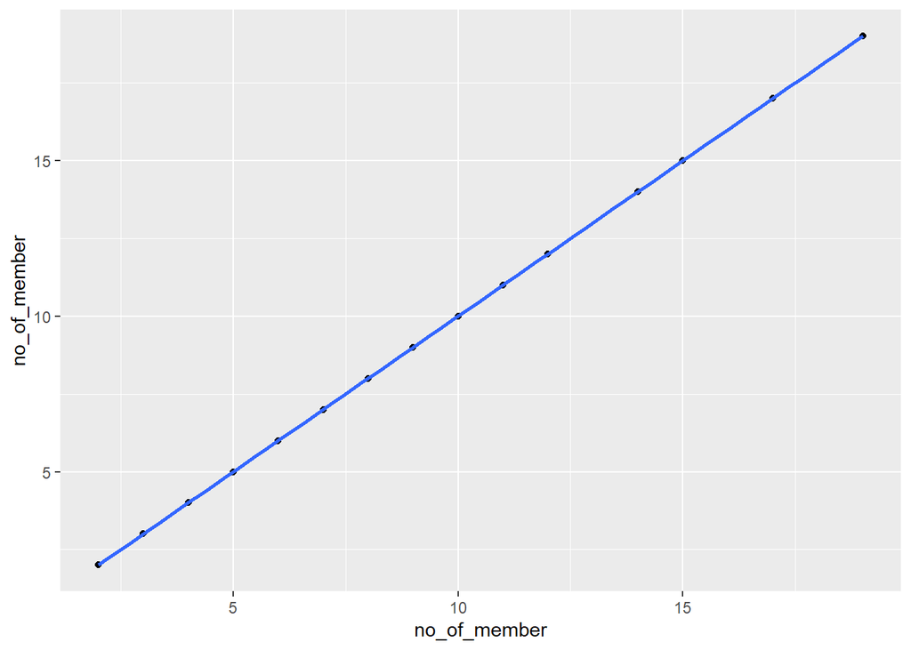

```r
ggplot(Datafile, aes(x=no_of_member, y=no_of_member))+
  geom_point() +
  geom_smooth() +
  coord_flip() +
  theme(legend.position = "none")
```

```r
Datafile
```

```
##     key_ID  village       interview_date no_membrs years_liv
## 1        1      God 2016-11-17T00:00:00Z         3         4
## 2        1      God 2016-11-17T00:00:00Z         7         9
## 3        3      God 2016-11-17T00:00:00Z        10        15
## 4        4      God 2016-11-17T00:00:00Z         7         6
## 5        5      God 2016-11-17T00:00:00Z         7        40
## 6        6      God 2016-11-17T00:00:00Z         3         3
## 7        7      God 2016-11-17T00:00:00Z         6        38
## 8        8 Chirodzo 2016-11-16T00:00:00Z        12        70
## 9        9 Chirodzo 2016-11-16T00:00:00Z         8         6
## 10      10 Chirodzo 2016-12-16T00:00:00Z        12        23
## 11      11      God 2016-11-21T00:00:00Z         6        20
## 12      12      God 2016-11-21T00:00:00Z         7        20
## 13      13      God 2016-11-21T00:00:00Z         6         8
## 14      14      God 2016-11-21T00:00:00Z        10        20
```

[output cut: 645 more lines]

#Data from R studio to train

```r
data()
```

```r
library(gapminder)
```

```r
gapData <- gapminder
```

#import the data from the web

```r
ca <- read_csv("https://raw.githubusercontent.com/scienceParkStudyGroup/r-lesson-based-on-ohi-data-training/gh-pages/data/ca.csv")
ca
```

```
## # A tibble: 789 × 7
##    region state code  park_name                     type          visitors  year
##    <chr>  <chr> <chr> <chr>                         <chr>            <dbl> <dbl>
##  1 PW     CA    CHIS  Channel Islands National Park National Park     1200  1963
##  2 PW     CA    CHIS  Channel Islands National Park National Park     1500  1964
##  3 PW     CA    CHIS  Channel Islands National Park National Park     1600  1965
##  4 PW     CA    CHIS  Channel Islands National Park National Park      300  1966
##  5 PW     CA    CHIS  Channel Islands National Park National Park    15700  1967
##  6 PW     CA    CHIS  Channel Islands National Park National Park    31000  1968
##  7 PW     CA    CHIS  Channel Islands National Park National Park    33100  1969
##  8 PW     CA    CHIS  Channel Islands National Park National Park    32000  1970
##  9 PW     CA    CHIS  Channel Islands National Park National Park    24400  1971
## 10 PW     CA    CHIS  Channel Islands National Park National Park    31947  1972
## # … with 779 more rows
## # ℹ Use `print(n = ...)` to see more rows
```

#exploaring data method

```r
glimpse(ca)
```

```
## Rows: 789
## Columns: 7
## $ region    <chr> "PW", "PW", "PW", "PW", "PW", "PW", "PW", "PW", "PW", "PW", …
## $ state     <chr> "CA", "CA", "CA", "CA", "CA", "CA", "CA", "CA", "CA", "CA", …
## $ code      <chr> "CHIS", "CHIS", "CHIS", "CHIS", "CHIS", "CHIS", "CHIS", "CHI…
## $ park_name <chr> "Channel Islands National Park", "Channel Islands National P…
## $ type      <chr> "National Park", "National Park", "National Park", "National…
## $ visitors  <dbl> 1200, 1500, 1600, 300, 15700, 31000, 33100, 32000, 24400, 31…
## $ year      <dbl> 1963, 1964, 1965, 1966, 1967, 1968, 1969, 1970, 1971, 1972, …
```

```r
str(ca)
```

```
## spec_tbl_df [789 × 7] (S3: spec_tbl_df/tbl_df/tbl/data.frame)
##  $ region   : chr [1:789] "PW" "PW" "PW" "PW" ...
##  $ state    : chr [1:789] "CA" "CA" "CA" "CA" ...
##  $ code     : chr [1:789] "CHIS" "CHIS" "CHIS" "CHIS" ...
##  $ park_name: chr [1:789] "Channel Islands National Park" "Channel Islands National Park" "Channel Islands National Park" "Channel Islands National Park" ...
##  $ type     : chr [1:789] "National Park" "National Park" "National Park" "National Park" ...
##  $ visitors : num [1:789] 1200 1500 1600 300 15700 ...
##  $ year     : num [1:789] 1963 1964 1965 1966 1967 ...
##  - attr(*, "spec")=
##   .. cols(
##   ..   region = col_character(),
##   ..   state = col_character(),
##   ..   code = col_character(),
##   ..   park_name = col_character(),
##   ..   type = col_character(),
##   ..   visitors = col_double(),
##   ..   year = col_double()
##   .. )
##  - attr(*, "problems")=<externalptr>
```

#st plot

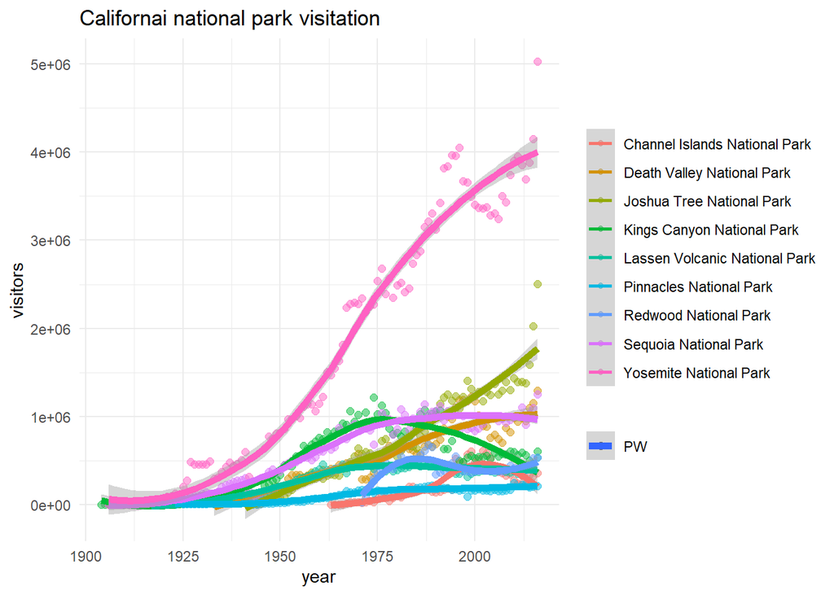

```r
ggplot(

  ca, aes(x=year, y= visitors, colour = park_name, size =region )
) +
  geom_point(alpha = 0.5) +
  geom_smooth() +
  theme(legend.position = "none") +
  labs(x="year", y="visitors", title="Californai national park visitation")+
  theme_minimal() +
  theme(
    legend.title = element_blank()

  )
```

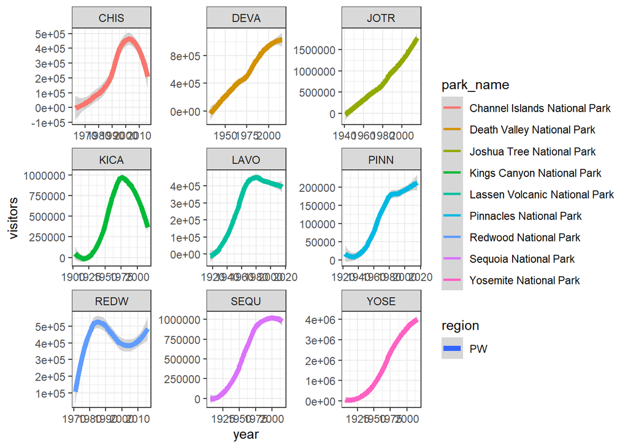

```r
ggplot(

  ca, aes(x=year, y= visitors, colour = park_name, size =region )
) +
  geom_smooth() +
  facet_wrap(~ code, scales = "free") +
  theme_bw()
```

```r
"R studio dral with arabic languge with xlsx bettwe than csv"
```

```
## [1] "R studio dral with arabic languge with xlsx bettwe than csv"
```

```r
ca$state
```

```
##   [1] "CA" "CA" "CA" "CA" "CA" "CA" "CA" "CA" "CA" "CA" "CA" "CA" "CA" "CA" "CA"
##  [16] "CA" "CA" "CA" "CA" "CA" "CA" "CA" "CA" "CA" "CA" "CA" "CA" "CA" "CA" "CA"
##  [31] "CA" "CA" "CA" "CA" "CA" "CA" "CA" "CA" "CA" "CA" "CA" "CA" "CA" "CA" "CA"
##  [46] "CA" "CA" "CA" "CA" "CA" "CA" "CA" "CA" "CA" "CA" "CA" "CA" "CA" "CA" "CA"
##  [61] "CA" "CA" "CA" "CA" "CA" "CA" "CA" "CA" "CA" "CA" "CA" "CA" "CA" "CA" "CA"
##  [76] "CA" "CA" "CA" "CA" "CA" "CA" "CA" "CA" "CA" "CA" "CA" "CA" "CA" "CA" "CA"
##  [91] "CA" "CA" "CA" "CA" "CA" "CA" "CA" "CA" "CA" "CA" "CA" "CA" "CA" "CA" "CA"
## [106] "CA" "CA" "CA" "CA" "CA" "CA" "CA" "CA" "CA" "CA" "CA" "CA" "CA" "CA" "CA"
## [121] "CA" "CA" "CA" "CA" "CA" "CA" "CA" "CA" "CA" "CA" "CA" "CA" "CA" "CA" "CA"
## [136] "CA" "CA" "CA" "CA" "CA" "CA" "CA" "CA" "CA" "CA" "CA" "CA" "CA" "CA" "CA"
## [151] "CA" "CA" "CA" "CA" "CA" "CA" "CA" "CA" "CA" "CA" "CA" "CA" "CA" "CA" "CA"
## [166] "CA" "CA" "CA" "CA" "CA" "CA" "CA" "CA" "CA" "CA" "CA" "CA" "CA" "CA" "CA"
## [181] "CA" "CA" "CA" "CA" "CA" "CA" "CA" "CA" "CA" "CA" "CA" "CA" "CA" "CA" "CA"
## [196] "CA" "CA" "CA" "CA" "CA" "CA" "CA" "CA" "CA" "CA" "CA" "CA" "CA" "CA" "CA"
## [211] "CA" "CA" "CA" "CA" "CA" "CA" "CA" "CA" "CA" "CA" "CA" "CA" "CA" "CA" "CA"
```

[output cut: 38 more lines]

```r
unique(ca$state)
```

```
## [1] "CA"
```

```r
"اضافه اسم الي ملف الى ملف
ignor
في خانه الملفات يمين تحت يخليه ماينرفع الى الجت هب حتى لو سويت كوممت"
```

```
## [1] "اضافه اسم الي ملف الى ملف \nignor\nفي خانه الملفات يمين تحت يخليه ماينرفع الى الجت هب حتى لو سويت كوممت"
```

```r
view(gapminder)
```

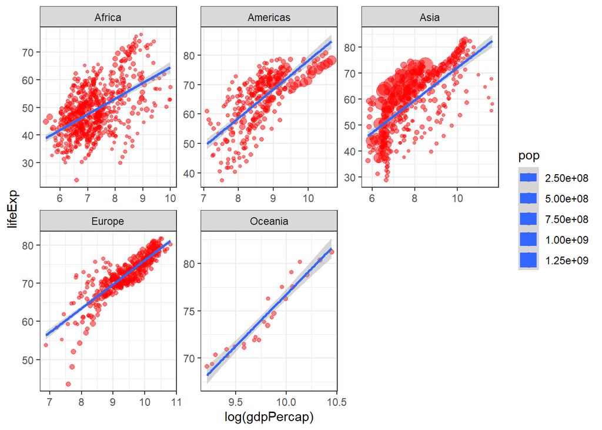

```r
  ggplot(gapminder, aes(x=log(gdpPercap),col= year, y= lifeExp, size =pop )
) +
  geom_point(alpha = 0.5, color = "red" )+
  geom_smooth(method = lm)+
  facet_wrap(~ continent, scale = "free")+
  theme_bw()
```

“install.packages(”ggplotAssist”) بعد م اثبتها بتطلع لي في Addins اعلى شي فووق تحت Help اختار منها ggplot Assit ثم بتفتح لي رابط مثل 192.186.1.1 فيها صفحه تساعدني تماما على انشاء ggplot للداتا عن طريق يوزر انتر فيس، و اعرف عن طريقها كل خصائص ال ggplot

#“plotly هي مكتبه تول الاشكال البلوتات الى اشكال تفاعليه ولكن عشان تشتغل لازم ادخل كود البلوت في <- ثم ادخله في كود ggplotly(اسم الي حطيته)

“ggplotly(pplloott)”

```r
 pplloott<- ggplot(gapminder, aes(x=log(gdpPercap),col= year, y= lifeExp, size =pop )
) +
  geom_point(alpha = 0.5, color = "red" )+
  geom_jitter()+
  geom_smooth(method = lm)+
  theme_bw()


ggsave(here("results","h0ere.png"), pplloott, dpi = 300 )
library(plotly)
"
rstat
اذا ابغا ادور عن اي شي في الار اكتب اسم الشي الي ابغا ادور عليه ثم اكتب هذى الاسم
مثلا:
plotly rstat install
,,
اذا ابغا اعرف عن اي شي
اكتب اسمه في قوقل و اكتب
sheetcheat.
"
```

```
## [1] "\nrstat\nاذا ابغا ادور عن اي شي في الار اكتب اسم الشي الي ابغا ادور عليه ثم اكتب هذى الاسم\nمثلا:\nplotly rstat install\n,,\nاذا ابغا اعرف عن اي شي \nاكتب اسمه في قوقل و اكتب\nsheetcheat.\n"
```

```r
"https://rweekly.org/
this is source from learning and being collabiraive with R community"
```

```
## [1] "https://rweekly.org/\nthis is source from learning and being collabiraive with R community"
```

#How to save data after minpulation

```r
write_csv(ca, here("results","ca.csv"))
```

```r
"changes in Yaml: which is in the top of this page"
```

```
## [1] "changes in Yaml: which is in the top of this page"
```

#“https://www.datadreaming.org/post/r-markdown-theme-gallery/” “this links has muti thems i can use in YAML ( in the top of this page)”, to publish my paper in internet for free, 1- kint the file 2- upside right ,3- RPubs then publsh.

# 4 library(prettydoc): it is used for design the yaml and it has a lot of thems i can check the website: “https://www.datadreaming.org/post/r-markdown-theme-gallery/” to know more about it

#ymlthis: it used to write yml code so need it to wrok with out errors becuse yml is sensetive to the spaces, after activate ymlthis lib it will show in Addins in the upper side of the Rstudio.

```r
library(ymlthis)
```